# Cardiovascular model in Appendix 5.2 | Simulation study

This notebook contains the code of the paper "Learning Physics between Digital Twins with Low-Fidelity Models and Physics-Informed Gaussian Processes". The models are fitted in rstan and the code is available in the folder "STAN/WK2".

#### Load packages

```r
# uncomment to install
# install.packages("rstan")
# install.packages("ggplot2")
# install.packages("latex2exp")
library(rstan)
library(ggplot2)
library(latex2exp)

rstan_options(auto_write = TRUE)
options(mc.cores = 3) # allocate 3 cores (for each model we run 3 chains in parallel)
# Load flow data
d = readRDS("Data/Inflow_time.rds")
```

#### Reality and modelling choice

$$\begin{align}
\mathcal{R}: \quad & \frac{d P(t)}{d t} + \frac{P(t)}{R_2C} = \frac{Q(t)}{C} \left (1 + \frac{ R_1}{R_2} \right ) + R_1 \frac{d Q(t)}{dt} \quad \text{ (the model we use to simulate data) }\text{ [WK3] }\\
\eta: \quad & Q(t) = \frac{1}{R}P(t) + C \frac{dP(t)}{dt} \quad \text{ (the misspesified model we use to fit the data) } \text{ [WK2] }
\end{align}$$

### Load posterior samples

First, we load the posterior samples from the fitted models obtained by the models in 'WK_simulation_study.Rmd'.

```r
# choose some reasonable physical parameter values
library(ggplot2)
dat = readRDS("Data/post_wk2.rds") # posterior data for all models
flow_time=readRDS("Data/Inflow_time.rds")
time=flow_time$time
post_nwd = dat$df_ycd
attach(dat)
attach(data)
lP_pr = lI_pr = list()
t1=Sys.time()
R_val=c(1,1.15, 1.3); C_val = c(1.1,0.95,1.25)
RC=expand.grid(R_val,C_val) # create all possible combinations
Rtrue=RC[,1]; Ctrue=RC[,2]
nc=2
nP=12
nI=14
Ns=9
set.seed(123)
Zvec=sample(seq(0.02,0.1,by=0.01), Ns, replace = T)
nP_pred=50; nI_pred=50;
tP_pred = time[round(seq(1,length(time), length.out = nP_pred))]
tI_pred = time[round(seq(1,length(time), length.out = nI_pred))]
```

### Model 1 (no-without delta $\delta(t)$, Figure 7)

Stan code:

```r
# writeLines(readLines("STAN/WK2/WK2_nodelta_pred.stan"))
```

We predict for each individual $m=1,\ldots,9$

```r
#----------------------------------------------------------------
# no-without delta
#----------------------------------------------------------------
post_nnd=l_df_nnd
N_samples = nrow(post_nnd[[1]])
# no-without delta model
for (i in 1:Ns){
  data_pred = list(nP=nc*nP, nI=nc*nI, tP=tP[i,], tI=tI[i,], yP=yP[i,], yI=yI[i,]
                   , tP_pred = tP_pred, tI_pred=tI_pred, nP_pred=nP_pred, nI_pred=nI_pred
                   , alpha=post_nnd[[i]]$alpha, rho=post_nnd[[i]]$rho
                   , sigmaP=post_nnd[[i]]$sigmaP, sigmaI=post_nnd[[i]]$sigmaI
                   , R=post_nnd[[i]]$R, C=post_nnd[[i]]$C, N_samples=N_samples
  )

  pred = stan(file = "STAN/WK2/WK2_nodelta_pred.stan",
              data = data_pred,
              chains = 1, iter = 1, seed=123,
              algorithm = "Fixed_param")
  ex_pred=extract(pred)
  Pvec = ex_pred$y_P
  Ivec = ex_pred$y_I
  P_post=matrix(NA, ncol = 4, nrow = nP_pred)
  # calculate mean and 95% CIs
  for(n in 1:nP_pred){
    ind=(1 +(n-1)*N_samples):(n*N_samples)
    v = Pvec[ind]
    P_post[n,] = c(mean(v), quantile(v, probs = 0.025), quantile(v, probs = 0.975),tP_pred[n])
  }
  I_post=matrix(NA, ncol = 4, nrow = nI_pred)
  for(n in 1:nI_pred){
    ind=(1 +(n-1)*N_samples):(n*N_samples)
    v = Ivec[ind]
    I_post[n,] = c(mean(v), quantile(v, probs = 0.025), quantile(v, probs = 0.975),tI_pred[n])
  }

  lP_pr[[i]]=P_post
  lI_pr[[i]]=I_post
}
```

```r
# prepare the data for plotting
ID = paste0(Zvec, " | ID = ", 1:Ns)
R1 = paste("expression(R[1] = )", Zvec)
P_nnd = data.frame(do.call(rbind, lP_pr))
P_nnd$ID = rep(ID, each = nP_pred)
P_nnd$t = rep(tP_pred, Ns)
colnames(P_nnd)[1:4] = c("mean", "lower", "upper", "time")
P_nnd$sharing = "no-without delta"

I_nnd = data.frame(do.call(rbind, lI_pr))
I_nnd$ID = rep(ID, each = nI_pred)
I_nnd$t = rep(tI_pred, Ns)
colnames(I_nnd)[1:4] = c("mean", "lower", "upper", "time")
I_nnd$sharing = "no-without delta"
```

### Model 2 (no-with $\delta(t)$, Figure 7)

Now we account for model discrepancy $\delta_m(x_m)\sim GP(0,K_\delta(x_m,x_m')),$ where we use the squared exponential kernel $K_\delta(x_m,x_m') = \alpha_m^2 \exp\left(-\frac{(x_m-x_m')^2}{2\rho_m^2}\right).$ More details on the prediction equations are given in the Appendix C.2.

Stan code:

```r
# writeLines(readLines("STAN/WK2/WK2_delta_pred.stan"))
```

We predict for each individual $m=1,\ldots,9$

```r
post_nwd=l_df_nwd
N_samples = nrow(post_nwd[[1]])
# no-with delta model
for (i in 1:Ns){
  data_pred = list(nP=nc*nP, nI=nc*nI, tP=tP[i,], tI=tI[i,], yP=yP[i,], yI=yI[i,]
                   , tP_pred = tP_pred, tI_pred=tI_pred, nP_pred=nP_pred, nI_pred=nI_pred
                   , alpha=post_nwd[[i]]$alpha, rho=post_nwd[[i]]$rho, alpha_d=post_nwd[[i]]$alpha_d
                   , rho_d=post_nwd[[i]]$rho_d, sigmaP=post_nwd[[i]]$sigmaP, sigmaI=post_nwd[[i]]$sigmaI
                   , R=post_nwd[[i]]$R, C=post_nwd[[i]]$C, N_samples=N_samples
  )

  pred = stan(file = "STAN/WK2/WK2_delta_pred.stan",
              data = data_pred,
              chains = 1, iter = 1, seed=123,
              algorithm = "Fixed_param")
  ex_pred=extract(pred)
  Pvec = ex_pred$y_P
  Ivec = ex_pred$y_I
  P_post=matrix(NA, ncol = 4, nrow = nP_pred)
  for(n in 1:nP_pred){
    ind=(1 +(n-1)*N_samples):(n*N_samples)
    v = Pvec[ind]
    P_post[n,] = c(mean(v), quantile(v, probs = 0.025), quantile(v, probs = 0.975),tP_pred[n])
  }
  I_post=matrix(NA, ncol = 4, nrow = nI_pred)
  for(n in 1:nI_pred){
    ind=(1 +(n-1)*N_samples):(n*N_samples)
    v = Ivec[ind]
    I_post[n,] = c(mean(v), quantile(v, probs = 0.025), quantile(v, probs = 0.975),tI_pred[n])
  }

  lP_pr[[i]]=P_post
  lI_pr[[i]]=I_post
}
```

```r
# prepare data for plotting
# ID = paste0(Zvec, " | ID = ", 1:Ns)
P_nwd = data.frame(do.call(rbind, lP_pr))
P_nwd$ID = rep(ID, each = nP_pred)
P_nwd$t = rep(tP_pred, Ns)
colnames(P_nwd)[1:4] = c("mean", "lower", "upper", "time")
P_nwd$sharing = "no-with delta"

I_nwd = data.frame(do.call(rbind, lI_pr))
I_nwd$ID = rep(ID, each = nI_pred)
I_nwd$t = rep(tI_pred, Ns)
colnames(I_nwd)[1:4] = c("mean", "lower", "upper", "time")
I_nwd$sharing = "no-with delta"
```

### Model 3 (yes/common $\delta(t)$, Figure 7)

We predict using the same equations as before, but now with the posterior distributions obtained by the fit of Model 3 (yes/common delta).

```r
post_ycd = list()

for(i in 1:Ns){
  v=c(paste0("alpha.",i), paste0("rho.",i), "alpha_d", "rho_d", "sigmaP", "sigmaI", paste0("R.",i), paste0("C.", i))
  df_temp=df_ycd[, v]
  colnames(df_temp)=c("alpha", "rho", "alpha_d", "rho_d", "sigmaP", "sigmaI", "R", "C")
  post_ycd[[i]]=df_temp
}

# yes/common delta model
for (i in 1:Ns){
  data_pred = list(nP=nc*nP, nI=nc*nI, tP=tP[i,], tI=tI[i,], yP=yP[i,], yI=yI[i,]
                   , tP_pred = tP_pred, tI_pred=tI_pred, nP_pred=nP_pred, nI_pred=nI_pred
                   , alpha=post_ycd[[i]]$alpha, rho=post_ycd[[i]]$rho, alpha_d=post_ycd[[i]]$alpha_d
                   , rho_d=post_ycd[[i]]$rho_d, sigmaP=post_ycd[[i]]$sigmaP, sigmaI=post_ycd[[i]]$sigmaI
                   , R=post_ycd[[i]]$R, C=post_ycd[[i]]$C, N_samples=N_samples
  )

  pred = stan(file = "STAN/WK2/WK2_delta_pred.stan",
              data = data_pred,
              chains = 1, iter = 1, seed=123,
              algorithm = "Fixed_param")
  ex_pred=extract(pred)
  Pvec = ex_pred$y_P
  Ivec = ex_pred$y_I
  P_post=matrix(NA, ncol = 4, nrow = nP_pred)
  for(n in 1:nP_pred){
    ind=(1 +(n-1)*N_samples):(n*N_samples)
    v = Pvec[ind]
    P_post[n,] = c(mean(v), quantile(v, probs = 0.025), quantile(v, probs = 0.975),tP_pred[n])
  }
  I_post=matrix(NA, ncol = 4, nrow = nI_pred)
  for(n in 1:nI_pred){
    ind=(1 +(n-1)*N_samples):(n*N_samples)
    v = Ivec[ind]
    I_post[n,] = c(mean(v), quantile(v, probs = 0.025), quantile(v, probs = 0.975),tI_pred[n])
  }

  lP_pr[[i]]=P_post
  lI_pr[[i]]=I_post
}
# ID = paste0(Zvec, "| ID = ", 1:Ns)
P_ycd = data.frame(do.call(rbind, lP_pr))
P_ycd$ID = rep(ID, each = nP_pred)
P_ycd$t = rep(tP_pred, Ns)
colnames(P_ycd)[1:4] = c("mean", "lower", "upper", "time")
P_ycd$sharing = "yes/common delta"

I_ycd = data.frame(do.call(rbind, lI_pr))
I_ycd$ID = rep(ID, each = nI_pred)
I_ycd$t = rep(tI_pred, Ns)
colnames(I_ycd)[1:4] = c("mean", "lower", "upper", "time")
I_ycd$sharing = "yes/common delta"
```

### Model 4 (yes/shared $\delta(t)$ in paper, Figure 7)

We predict using the same equations as before, but now with the posterior distributions obtained by the fit of Model 4 (yes/shared delta).

```r
#-------------------------------------------------------
# yes/ shared delta
#----------------------------------------------------------------
post_ysd = list()

for(i in 1:Ns){
  v=c(paste0("alpha.",i), paste0("rho.",i), paste0("alpha_d.",i), paste0("rho_d.",i), "sigmaP", "sigmaI", paste0("R.",i), paste0("C.", i))
  df_temp=df_ysd[, v]
  colnames(df_temp)=c("alpha", "rho", "alpha_d", "rho_d", "sigmaP", "sigmaI", "R", "C")
  post_ysd[[i]]=df_temp
}

# yes/common delta model
for (i in 1:Ns){
  data_pred = list(nP=nc*nP, nI=nc*nI, tP=tP[i,], tI=tI[i,], yP=yP[i,], yI=yI[i,]
                   , tP_pred = tP_pred, tI_pred=tI_pred, nP_pred=nP_pred, nI_pred=nI_pred
                   , alpha=post_ysd[[i]]$alpha, rho=post_ysd[[i]]$rho, alpha_d=post_ysd[[i]]$alpha_d
                   , rho_d=post_ysd[[i]]$rho_d, sigmaP=post_ysd[[i]]$sigmaP, sigmaI=post_ysd[[i]]$sigmaI
                   , R=post_ysd[[i]]$R, C=post_ysd[[i]]$C, N_samples=N_samples
  )

  pred = stan(file = "STAN/WK2/WK2_delta_pred.stan",
              data = data_pred,
              chains = 1, iter = 1, seed=123,
              algorithm = "Fixed_param")
  ex_pred=extract(pred)
  Pvec = ex_pred$y_P
  Ivec = ex_pred$y_I
  P_post=matrix(NA, ncol = 4, nrow = nP_pred)
  for(n in 1:nP_pred){
    ind=(1 +(n-1)*N_samples):(n*N_samples)
    v = Pvec[ind]
    P_post[n,] = c(mean(v), quantile(v, probs = 0.025), quantile(v, probs = 0.975),tP_pred[n])
  }
  I_post=matrix(NA, ncol = 4, nrow = nI_pred)
  for(n in 1:nI_pred){
    ind=(1 +(n-1)*N_samples):(n*N_samples)
    v = Ivec[ind]
    I_post[n,] = c(mean(v), quantile(v, probs = 0.025), quantile(v, probs = 0.975),tI_pred[n])
  }

  lP_pr[[i]]=P_post
  lI_pr[[i]]=I_post
}
P_ysd = data.frame(do.call(rbind, lP_pr))
P_ysd$ID = rep(ID, each = nP_pred)
P_ysd$t = rep(tP_pred, Ns)
colnames(P_ysd)[1:4] = c("mean", "lower", "upper", "time")
P_ysd$sharing = "yes/shared delta"

I_ysd = data.frame(do.call(rbind, lI_pr))
I_ysd$ID = rep(ID, each = nI_pred)
I_ysd$t = rep(tI_pred, Ns)
colnames(I_ysd)[1:4] = c("mean", "lower", "upper", "time")
I_ysd$sharing = "yes/shared delta"
```

#### Plot pressure predictions (Figure 5 in Appendix)

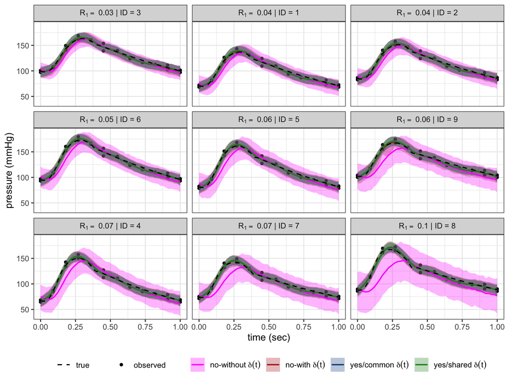

```r
P_pred = rbind(P_nwd, P_ysd, P_ycd, P_nnd)
df_true = dat$P_true
P_true = data.frame(P=as.vector(dat$P_true), t = rep(time,Ns), ID = rep(ID, each = length(time)))

P_obs = data.frame(P=as.vector(t(yP)), t = as.vector(t(tP)), ID = rep(ID, each = nc*nP))

# New facet label names
appender = function(string) {
  TeX(paste("$R_1= $", string))
}
lbl=c(latex2exp('no-without $\\delta(t)$'),
                 latex2exp('no-with $\\delta(t)$'),
                 latex2exp('yes/common $\\delta(t)$'),
                 latex2exp('yes/shared $\\delta(t)$'))
pl_WK_pred_P=ggplot()+
  geom_point(data=P_obs, aes(x=t, y=P, shape="observed"))+
  geom_ribbon(data = P_pred, aes(x=t,ymin=lower,ymax=upper, fill=sharing),alpha=0.3)+# alpha=0.38
  geom_line(data=P_pred, aes(x=t, y=mean, color= sharing), size=0.7)+
  geom_line(data=P_true, aes(x=t, y=P, linetype="true"), size=0.6)+
  facet_wrap(~ID, nrow = 3,labeller = as_labeller(appender, default = label_parsed))+
  theme_bw()+
  xlab("time (sec)")+ylab("pressure (mmHg)")+
  theme(legend.position = "bottom", legend.title = element_blank())+
  scale_color_manual(
    breaks=c('no-without delta','no-with delta', "yes/common delta", "yes/shared delta", "true"),
    values=c("magenta","firebrick","dodgerblue4", "forestgreen", "black"),
    label=lbl
  )+
  scale_linetype_manual(breaks=c('no-without delta','no-with delta', "yes/common delta", "yes/shared delta", "true"),
                        values=c(1,1,1, 1, 2)
  )+
  scale_fill_manual(
    breaks=c('no-without delta','no-with delta', "yes/common delta", "yes/shared delta"),
    values=c("magenta","firebrick","dodgerblue4", "forestgreen"),
    label=lbl
  )

pl_WK_pred_P
```

```r
# ggsave("Figs/WK_pred_P.pdf", plot = pl_WK_pred_P, width = 20, height = 15, units = "cm")
```

#### prediction rmses

```r
# P_nwd, P_ysd, P_ycd, P_nnd
rmse = function(actual,pred) sqrt(mean((actual - pred)^2))
pred_nnd = P_nnd[,c("mean", "lower", "upper")]
pred_nwd = P_nwd[,c("mean", "lower", "upper")]
pred_ycd = P_ycd[,c("mean", "lower", "upper")]
pred_ysd = P_ysd[,c("mean", "lower", "upper")]
N_pred=nP_pred
pred_nnd$ID = rep(1:Ns, each=N_pred)
pred_nwd$ID = rep(1:Ns, each=N_pred)
pred_ycd$ID = rep(1:Ns, each=N_pred)
pred_ysd$ID = rep(1:Ns, each=N_pred)

ind_pred = round(seq(1,length(time), length.out = nP_pred))

rmse_nnd = rmse_nwd = rmse_ycd = rmse_ysd = rep(NA,Ns)
for(i in 1:Ns){
 rmse_nnd[i] = rmse(df_true[ind_pred,i], pred_nnd[pred_nnd$ID == i,"mean"])
 rmse_nwd[i] = rmse(df_true[ind_pred,i], pred_nwd[pred_nwd$ID == i,"mean"])
 rmse_ycd[i] = rmse(df_true[ind_pred,i], pred_ycd[pred_ycd$ID == i,"mean"])
 rmse_ysd[i] = rmse(df_true[ind_pred,i], pred_ysd[pred_ysd$ID == i,"mean"])
}

rmses_WK2_sim = colMeans(cbind(rmse_nnd,rmse_nwd,rmse_ycd,rmse_ysd))
df_rmses_WK2_sim=data.frame(matrix(rmses_WK2_sim,nrow = 1))
colnames(df_rmses_WK2_sim) = c("nnd", "nwd", "ycd", "ysd")
rownames(df_rmses_WK2_sim) = "WK simulation"
round(df_rmses_WK2_sim,2)
```

|  | nnd | nwd | ycd | ysd |
| --- | --- | --- | --- | --- |
| WK simulation | 9.49 | 2.44 | 2.38 | 2.37 |

```r
# saveRDS(df_rmses_WK2_sim, "Data/rmse_WK2_sim.rds")
```

#### Plot flow predictions (Figure 6 in Appendix)

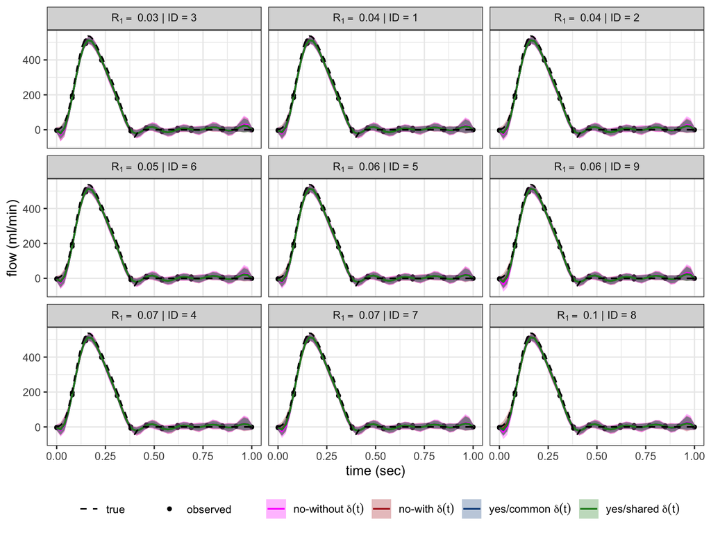

```r
I_pred = rbind(I_nwd, I_ysd, I_ycd, I_nnd)
df_true_I = dat$I_true
I_true = data.frame(I=as.vector(flow_time$inflow), t = rep(time,Ns), ID = rep(ID, each = length(time)))

I_obs = data.frame(I=as.vector(t(yI)), t = as.vector(t(tI)), ID = rep(ID, each = nc*nI))

pl_WK_pred_I=ggplot()+
  geom_point(data=I_obs, aes(x=t, y=I, shape="observed"))+
  geom_ribbon(data = I_pred, aes(x=t,ymin=lower,ymax=upper, fill=sharing),alpha=0.3)+# alpha=0.38
  geom_line(data=I_pred, aes(x=t, y=mean, color= sharing), size=0.7)+
  geom_line(data=I_true, aes(x=t, y=I, linetype="true"), size=0.6)+
  facet_wrap(~ID, nrow = 3,labeller = as_labeller(appender, default = label_parsed))+
  theme_bw()+
  xlab("time (sec)")+ylab("flow (ml/min)")+
  theme(legend.position = "bottom", legend.title = element_blank())+
  scale_color_manual(
    breaks=c('no-without delta','no-with delta', "yes/common delta", "yes/shared delta", "true"),
    values=c("magenta","firebrick","dodgerblue4", "forestgreen", "black"),
    label=lbl
  )+
  scale_linetype_manual(breaks=c('no-without delta','no-with delta', "yes/common delta", "yes/shared delta", "true"),
                        values=c(1,1,1, 1, 2)
  )+
  scale_fill_manual(
    breaks=c('no-without delta','no-with delta', "yes/common delta", "yes/shared delta"),
    values=c("magenta","firebrick","dodgerblue4", "forestgreen"),
    label=lbl
  )

pl_WK_pred_I
```

```r
# ggsave("Figs/WK_pred_I.pdf", plot = pl_WK_pred_I, width = 20, height = 15, units = "cm")
```

#### Plot posteriors of R for all individuals (Figure 3 in Appendix)

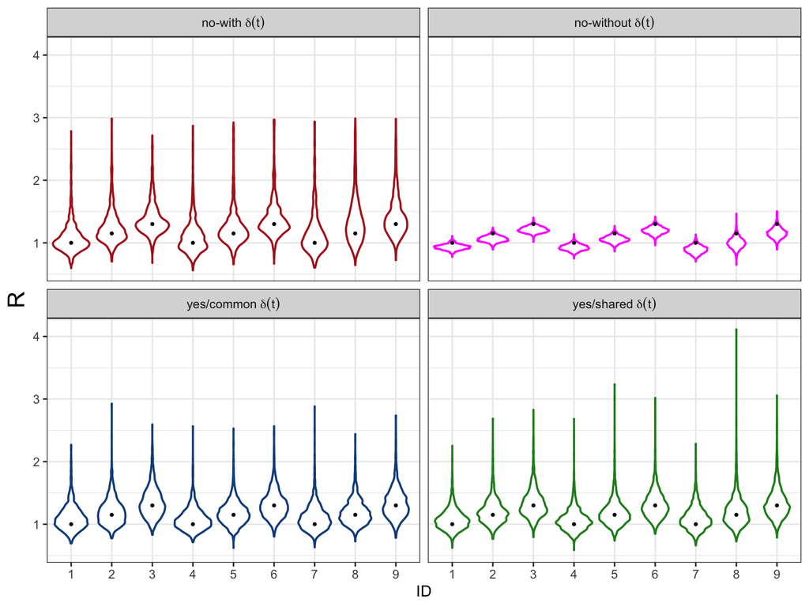

```r
R_nnd = R_nwd = R_ycd = R_ysd = C_nnd = C_nwd = C_ycd = C_ysd = c()

for(i in 1:Ns){
  R_temp = post_nnd[[i]]$R
  R_nnd = c(R_nnd, R_temp)
  R_temp = post_nwd[[i]]$R
  R_nwd = c(R_nwd, R_temp)
  R_temp = post_ycd[[i]]$R
  R_ycd = c(R_ycd, R_temp)
  R_temp = post_ysd[[i]]$R
  R_ysd = c(R_ysd, R_temp)
  C_temp = post_nnd[[i]]$C
  C_nnd = c(C_nnd, C_temp)
  C_temp = post_nwd[[i]]$C
  C_nwd = c(C_nwd, C_temp)
  C_temp = post_ysd[[i]]$C
  C_ycd = c(C_ycd, C_temp)
  C_temp = post_ycd[[i]]$C
  C_ysd = c(C_ysd, C_temp)
}
id_post = rep(as.factor(1:Ns), each = N_samples)
# shr = c('no-without delta','no-with delta', "yes/common delta", "yes/shared delta")
shr = c('no-without','no-with', "yes/common", "yes/shared")
Rpost=data.frame(R = c(R_nnd, R_nwd, R_ycd, R_ysd), ID = rep(id_post,4), sharing = rep(rep(shr, each = Ns*N_samples),4))
Cpost=data.frame(C = c(C_nnd, C_nwd, C_ycd, C_ysd), ID = rep(id_post,4), sharing = rep(rep(shr, each = Ns*N_samples),4))

lbl_post=c(TeX('no-without $\\delta(t)$'),TeX('no-with $\\delta(t)$')
           ,TeX('yes/common $\\delta(t)$'),TeX('yes/shared $\\delta(t)$'))

# New facet label names
appender2 = function(string) {
  TeX(paste(string, "$\\delta(t)$"))
}
# R post
(pl_R=ggplot() +
    geom_violin(data = Rpost, aes(x = ID, y=R, color = sharing), size=0.7)+
    theme_bw()+
    theme(axis.title.y = element_text(size = rel(1.5)), legend.position = "none")+
    geom_point(data = data.frame(R = Rtrue, ID = as.factor(1:Ns)), aes(x = ID, y = R, shape = "true"),size=1)+
    facet_wrap(sharing~., labeller = as_labeller(appender2, default = label_parsed))+
    xlab("ID")+
    scale_color_manual(
      # breaks=c('no-without delta', 'no-with delta', "yes/common delta", "yes/shared delta"),
      breaks=c('no-without', 'no-with', "yes/common", "yes/shared"),
      values=c("magenta","firebrick","dodgerblue4", "forestgreen"))
)
```

```r
# ggsave("Figs/post_WK_R.pdf", plot = pl_R, width = 18, height = 12, units = "cm")
```

#### Plot posteriors of C for all individuals (Figure 3 in Appendix)

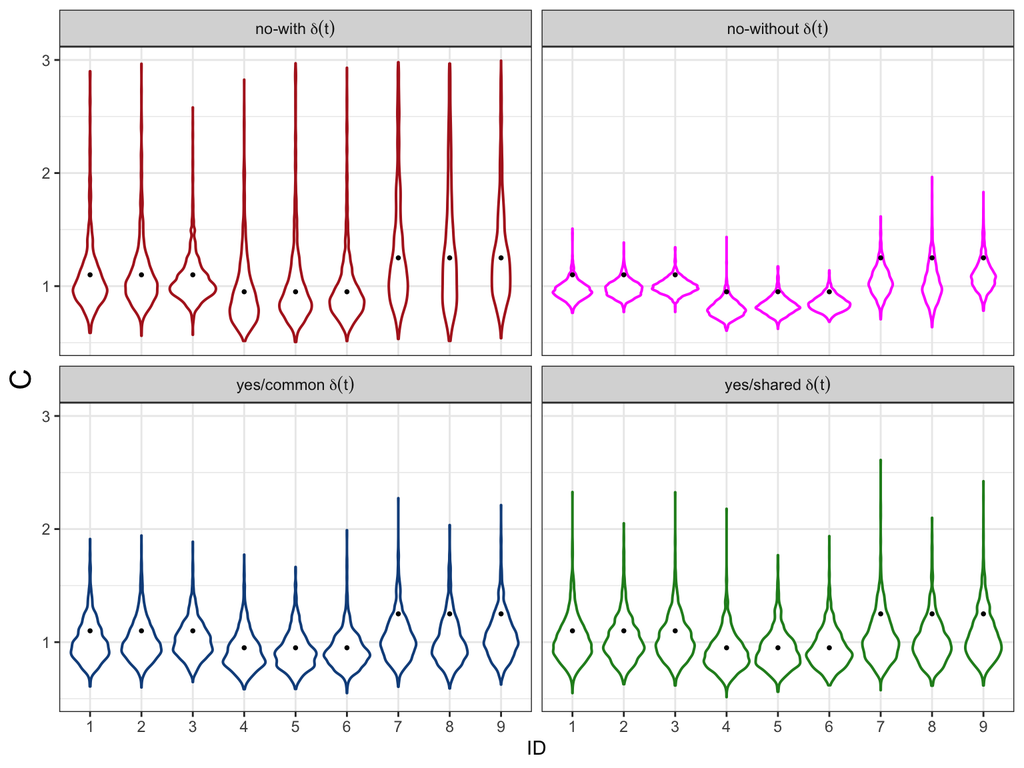

```r
# C post
(pl_C=ggplot() +
  geom_violin(data = Cpost, aes(x = ID, y=C, color = sharing),size=0.7)+
  theme_bw()+
  theme(axis.title.y = element_text(size = rel(1.5)), legend.position = "none")+
  geom_point(data = data.frame(C = Ctrue, ID = as.factor(1:Ns)), aes(x = ID, y = C, shape = "true"),size=1)+
  facet_wrap(sharing~., labeller = as_labeller(appender2, default = label_parsed))+
  xlab("ID")+
  scale_color_manual(
    breaks=c('no-without', 'no-with', "yes/common", "yes/shared"),
    values=c("magenta","firebrick","dodgerblue4", "forestgreen")))
```

```r
# ggsave("Figs/post_WK_C.pdf", plot = pl_C, width = 18, height = 12, units = "cm")
```